# Probability and Statistics

# Lab Assignment 1: Naive Bayes Classifier

### *Anastasiia Shvets, Anastasiia Beheni, Nazarii Peniaha*

## Introduction

During the past three weeks, we learned a couple of essential notions and theorems, and one of the most important among them is the *Bayes theorem*.

One of its applications is **Naive Bayes classifier**, which is a probabilistic classifier whose aim is to determine which class some observation probably belongs to by using the Bayes formula:
$$\mathsf{P}(\mathrm{class}\mid
\mathrm{observation})=\frac{\mathsf{P}(\mathrm{observation}\mid\mathrm{class})\mathsf{P}(\mathrm{class})}{\mathsf{P}(\mathrm{observation})}$$

Under the strong independence assumption, one can calculate $\mathsf{P}(\mathrm{observation} \mid \mathrm{class})$ as
$$\mathsf{P}(\mathrm{observation}) =
\prod_{i=1}^{n} \mathsf{P}(\mathrm{feature}_i), \qquad
\mathsf{P}(\mathrm{observation} \mid \mathrm{class}) = \prod_{i=1}^{n}
\mathsf{P}(\mathrm{feature}_i \mid \mathrm{class}),$$
where $n$ is the total number of features describing a given observation. Thus, $\mathsf{P}(\mathrm{class}|\mathrm{observation})$ now can be calculated as

$$\mathsf{P}(\mathrm{class} \mid
\mathrm{\mathrm{observation}}) = \mathsf{P}(\mathrm{class})\times
\prod_{i=1}^{n}\frac{\mathsf{P}(\mathrm{feature}_i\mid
\mathrm{class})}{\mathsf{P}(\mathrm{feature}_i)}\tag{1}$$

## Data description

- **0 - authors** This data set consists of citations of three famous writers: Edgar Alan Poe, Mary Wollstonecraft Shelley and HP Lovecraft. The task with this data set is to classify a piece of text with the author who was more likely to write it.

```r
# here goes a list of recommended libraries,
# though you may install other ones if they are needed
library(tidytext)
library(readr)
library(dplyr)
```

```r
library(ggplot2)
```

```r
# list.files(getwd())
list.files("data/0-authors")
```

```
## [1] "final_data_fr.csv" "test.csv"          "train.csv"
```

```r
test_path <- "data/0-authors/test.csv"
train_path <- "data/0-authors/train.csv"
stop_words <- read_file("stop_words.txt")
# https://stackoverflow.com/questions/27195912/why-does-strsplit-return-a-list
splitted_stop_words <- strsplit(stop_words, split='\n')
splitted_stop_words <- splitted_stop_words[[1]]
```

```r
train <-  read.csv(file = train_path, stringsAsFactors = FALSE)
test <-  read.csv(file = test_path, stringsAsFactors = FALSE)
```

```r
# note the power functional features of R bring us!
tidy_text <- unnest_tokens(train, 'splitted', 'text', token="words") %>%
             filter(!splitted %in% stop_words)
counter <- tidy_text %>% count(splitted,sort=TRUE)
#some other data pre-processing
lovecraft <- subset(tidy_text, author == "HP Lovecraft") %>% count(splitted, sort = TRUE)
poe <- subset(tidy_text, author == "Edgar Alan Poe") %>% count(splitted, sort = TRUE)
mary <- subset(tidy_text, author == "Mary Wollstonecraft Shelley ") %>% count(splitted, sort = TRUE)
counter <- merge(counter, lovecraft, by = "splitted", all = TRUE)
counter <- merge(counter, poe, by = "splitted", all = TRUE)
counter <- merge(counter, mary, by = "splitted", all = TRUE)
colnames(counter)[1] = "word"
colnames(counter)[2] = "total"
colnames(counter)[3] = "Lovecraft"
colnames(counter)[4] = "Poe"
colnames(counter)[5] = "Shelley"
counter[is.na(counter)]<-0
```

## Classifier implementation

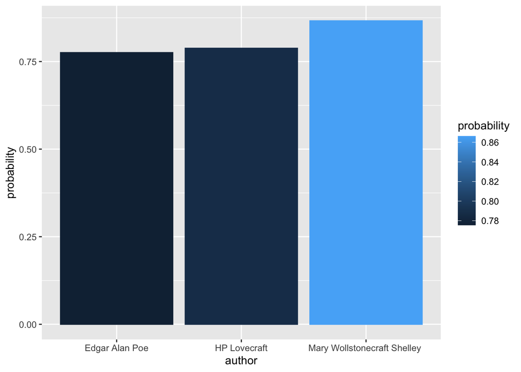

```r
naiveBayes <- setRefClass("naiveBayes",
       fields = list(),
       methods = list(
                    fit = function(){
                      total_author_amount_vector <<- c(sum(counter$Lovecraft), sum(counter$Poe), sum(counter$Shelley))
                      total_amount_of_unique_words <<- nrow(counter)
                      total_amount_of_unique_words

                      counter$Prob_word_given_Lovecraft <<- with(counter, (Lovecraft+1)/(total_author_amount_vector[1]+total_amount_of_unique_words))
                      counter$Prob_word_given_Poe <<- with(counter, (Poe+1)/(total_author_amount_vector[2]+total_amount_of_unique_words))
                      counter$Prob__word_given_Shelley <<- with(counter, (Shelley+1)/(total_author_amount_vector[3]+total_amount_of_unique_words))

                      total_amount_of_words <<- sum(counter$total)

                      prob_author_vector <<- c(total_author_amount_vector/total_amount_of_words)
                      },

                    predict = function(message){
                      message <- strsplit(message, " ")[[1]]
                      message_data <- data_frame(text = message)
                      new_splitted_mes <- unnest_tokens(message_data, 'text', 'text', token="words") %>%
                                      filter(!text %in% splitted_stop_words)

                      prob_message_lovecraft = 1
                      prob_message_poe = 1
                      prob_message_shelley= 1

                      for (wrd in new_splitted_mes$text) {

                          word_prob_lovecraft <- ifelse(wrd %in% counter$word,
                            counter %>% filter(word==wrd) %>% pull(Prob_word_given_Lovecraft),
                            1/(total_author_amount_vector[1]+total_amount_of_unique_words))

                          word_prob_poe <- ifelse(wrd %in% counter$word,
                            counter %>% filter(word==wrd) %>% pull(Prob_word_given_Poe),
                            1/(total_author_amount_vector[2]+total_amount_of_unique_words))

                          word_prob_shelley <- ifelse(wrd %in% counter$word,
                            counter %>% filter(word==wrd) %>% pull(Prob__word_given_Shelley),
                            1/(total_author_amount_vector[3]+total_amount_of_unique_words))


                      prob_message_lovecraft = prob_message_lovecraft * word_prob_lovecraft
                      prob_message_poe = prob_message_poe * word_prob_poe
                      prob_message_shelley= prob_message_shelley * word_prob_shelley

                    }

                      lst <- list(prob_message_lovecraft*prob_author_vector[1], prob_message_poe*prob_author_vector[2],
                                prob_message_shelley*prob_author_vector[3])
                      index <- which.max(lst)
                      lst_authors <- list("HP Lovecraft", "Edgar Alan Poe", "Mary Wollstonecraft Shelley ")
                      return(lst_authors[index])

            },

                    score = function(){
                      path = "data/0-authors/test.csv"
                      data_from_file <- read.csv(path)
                      data_from_file <- data_from_file[, (3:4)]
                      for (i in 1:nrow(data_from_file)) {
                        data_from_file[i, "predicted"] = naiveBayes()$predict(data_from_file$text[i])
                        data_from_file[i, "result"] = ifelse(data_from_file$author[i] == data_from_file$predicted[i], 1, 0)
                      }
                      # data_from_file

                      # checker <- read.csv("data/0-authors/final_data_fr.csv")

                      edgar_data <<- data_from_file %>% filter(author == "Edgar Alan Poe") %>% select(author, predicted, result)
                      edgar_prob = sum(edgar_data$result)/nrow(edgar_data)

                      mary_data <<- data_from_file %>% filter(author == "Mary Wollstonecraft Shelley ") %>% select(author, predicted, result)
                      mary_prob = sum(mary_data$result)/nrow(mary_data)

                      hp_data <<- data_from_file %>% filter(author == "HP Lovecraft") %>% select(author, predicted, result)
                      hp_prob = sum(hp_data$result)/nrow(mary_data)

                      author <- c("HP Lovecraft", "Mary Wollstonecraft Shelley ", "Edgar Alan Poe")
                      probability <- c(hp_prob, mary_prob, edgar_prob)

                      new_data <- data.frame(author, probability)
                      new_data %>%
                        ggplot(aes(author, probability, colour = probability))+
                        geom_bar(stat = "identity", aes(fill = probability))

                }

))
model = naiveBayes()
model$fit()
model$score()
```

## Summarizing mistakes

```r
mary_false_data <- mary_data %>% filter(result == 0 & author =="Mary Wollstonecraft Shelley ")
hp_in_mary <<- 0
edgar_in_mary <<- 0
for (name in mary_false_data$predicted) {
  if (name == "HP Lovecraft"){
    hp_in_mary = hp_in_mary + 1
  } else {
    edgar_in_mary = edgar_in_mary + 1
  }
}
print("Mistakes in Mary Wollstonecraft Shelley:")
```

```
## [1] "Mistakes in Mary Wollstonecraft Shelley:"
```

```r
print(hp_in_mary + edgar_in_mary)
```

```
## [1] 246
```

```r
print("Confused with HP Lovecraft:")
```

```
## [1] "Confused with HP Lovecraft:"
```

```r
print(hp_in_mary)
```

```
## [1] 124
```

```r
print("Confused with Edgar Alan Poe:")
```

```
## [1] "Confused with Edgar Alan Poe:"
```

```r
print(edgar_in_mary)
```

```
## [1] 122
```

```r
edgar_false_data <- edgar_data %>% filter(result == 0 & author =="Edgar Alan Poe")
mary_in_edgar <<- 0
hp_in_edgar <<- 0
for (name in edgar_false_data$predicted) {
  if (name == "HP Lovecraft"){
    hp_in_edgar = hp_in_edgar + 1
  } else {
    mary_in_edgar = mary_in_edgar + 1
  }
}
print("Mistakes in Edgar Alan Poe:")
```

```
## [1] "Mistakes in Edgar Alan Poe:"
```

```r
print(hp_in_edgar + mary_in_edgar)
```

```
## [1] 533
```

```r
print("Confused with HP Lovecraft:")
```

```
## [1] "Confused with HP Lovecraft:"
```

```r
print(hp_in_edgar)
```

```
## [1] 232
```

```r
print("Confused with Mary Wollstonecraft Shelley:")
```

```
## [1] "Confused with Mary Wollstonecraft Shelley:"
```

```r
print(mary_in_edgar)
```

```
## [1] 301
```

```r
hp_false_data <- hp_data %>% filter(result == 0 & author =="HP Lovecraft")
mary_in_hp <<- 0
edgar_in_hp <<- 0
for (name in hp_false_data$predicted) {
  if (name == "Edgar Alan Poe"){
    edgar_in_hp = edgar_in_hp + 1
  } else {
    mary_in_hp = mary_in_hp + 1
  }
}
print("Mistakes in HP Lovecraft:")
```

```
## [1] "Mistakes in HP Lovecraft:"
```

```r
print(mary_in_hp + edgar_in_hp)
```

```
## [1] 212
```

```r
print("Confused with Edgar Alan Poe:")
```

```
## [1] "Confused with Edgar Alan Poe:"
```

```r
print(edgar_in_hp)
```

```
## [1] 115
```

```r
print("Confused with Mary Wollstonecraft Shelley:")
```

```
## [1] "Confused with Mary Wollstonecraft Shelley:"
```

```r
print(mary_in_hp)
```

```
## [1] 97
```

## Measure effectiveness of your classifier

```r
accuracy_path = "data/0-authors/final_data_fr.csv"
print(getwd())
```

```
## [1] "/Users/igor/Desktop/P&SR"
```

```r
accur <- read.csv(accuracy_path)
print("Effectiveness of our classifier =")
```

```
## [1] "Effectiveness of our classifier ="
```

```r
print(sum(accur$result)/nrow(accur)*100)
```

```
## [1] 83.0269
```

```r
fails <- subset(accur, result == 0)
fails$len <- lengths(gregexpr("\\W+", fails$text))
succ <- subset(accur, result == 1)
succ$len <- lengths(gregexpr("\\W+", succ$text))
average_fail_len = sum((fails$len)/nrow(accur))
average_succ_len = sum((succ$len)/nrow(accur))
print("The probability of successful classification depends on the message lenght")
```

[output not shown]

```r
print("Average lenght of failed message =")
```

```
## [1] "Average lenght of failed message ="
```

```r
average_fail_len
```

```
## [1] 4.022472
```

```r
print("Average lenght of successful message =")
```

```
## [1] "Average lenght of successful message ="
```

```r
average_succ_len
```

```
## [1] 23.0875
```

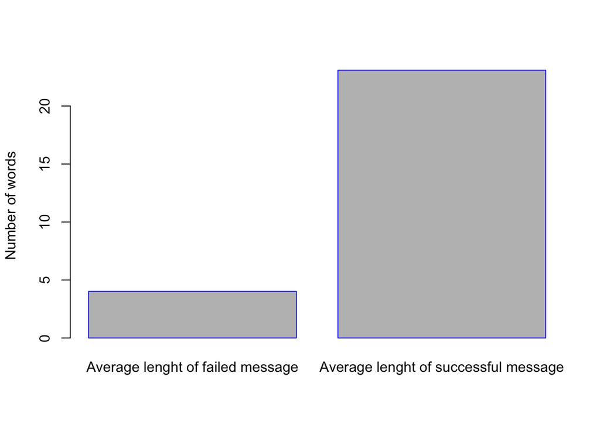

```r
gr <- c(average_fail_len, average_succ_len)
barplot(gr, ylab="Number of words", names.arg=c("Average lenght of failed message", "Average lenght of successful message"), border="blue")
```

## Conclusions

- We used Naive Bayes Classifier which uses Bayes’s formula for conditional probability to determine the authorship of the given text excerpt
- Pros of this approach: The algoright is easy to understand and implement We got pretty high accuracy (83%) It can be used for both binary and multi-class classifications
- Cons: It assumes that all the features are independent. While it might sound great in theory, in real life, you’ll hardly find a set of independent features We have to deal (by Laplace smoothing) with the problem when the word wasn’t presented in train set so our probability equals to one